# Phase1

## Table of Content

*Introduction

### 1.Introduction:

Every year around 17 million people die due to Cardiovascular diseases. This mainly consists of heart failures. There are various laboratory tests available through which a person can obtain some useful results. Results of these different tests and some daily habits and some other features can be used in Machine Learning to predict the survival rate of a person from Cardiovascular disease. Which can be unseen by a doctor.

#### 1.1.Dataset Source:

Chicco, D., 2020. UCI Machine Learning Repository: Heart failure clinical records Data Set. [online] Archive.ics.uci.edu. Available at: https://archive.ics.uci.edu/ml/datasets/Heart+failure+clinical+records [Accessed 10 April 2021].

#### 1.2.Dataset Details:

This dataset consists of records of heart failure patients. It has 299 records and 13 attributes in it. It is a multivariate dataset. Different clinical features are provided in this dataset. There are 105 women and 194 men in this dataset ranging between age group of 40 and 95.

#### 1.3.Dataset Features:

[output not shown]

#### 1.4.Target Feature:

The Death Event attribute is the target variable in our dataset. We will use this target variable to predict the number of survived patients based upon the clinical test results provided in the given attributes. We make our model based upon the attributes that give us the best results.

### 3.Data Cleaning &Preprocessing:

In our dataset we have performed the necessary data cleaning and preprocessing steps. We have checked for the missing values and null values in our dataset. We have also checked for negative values in age attribute and even for some outliers for age. So according to our analysis there is no data cleaning and Preprocessing required in the given dataset.

```python
#Importing Libraries
import warnings
import pandas as pd
import matplotlib.pyplot as plt
import seaborn as sns
```

```python
#supress warnings
warnings.filterwarnings("ignore")
pd.set_option('display.max_columns', None)
```

```python
#load dataset
data_frame = pd.read_csv("heart_failure_clinical_records_dataset.csv")
```

```python
data_frame.head(10)
```

|  | age | anaemia | creatinine_phosphokinase | diabetes | ejection_fraction | high_blood_pressure | platelets | serum_creatinine | serum_sodium | sex | smoking | time | DEATH_EVENT |
| --- | --- | --- | --- | --- | --- | --- | --- | --- | --- | --- | --- | --- | --- |
| 0 | 75.0 | 0 | 582 | 0 | 20 | 1 | 265000.00 | 1.9 | 130 | 1 | 0 | 4 | 1 |
| 1 | 55.0 | 0 | 7861 | 0 | 38 | 0 | 263358.03 | 1.1 | 136 | 1 | 0 | 6 | 1 |
| 2 | 65.0 | 0 | 146 | 0 | 20 | 0 | 162000.00 | 1.3 | 129 | 1 | 1 | 7 | 1 |
| 3 | 50.0 | 1 | 111 | 0 | 20 | 0 | 210000.00 | 1.9 | 137 | 1 | 0 | 7 | 1 |
| 4 | 65.0 | 1 | 160 | 1 | 20 | 0 | 327000.00 | 2.7 | 116 | 0 | 0 | 8 | 1 |
| 5 | 90.0 | 1 | 47 | 0 | 40 | 1 | 204000.00 | 2.1 | 132 | 1 | 1 | 8 | 1 |
| 6 | 75.0 | 1 | 246 | 0 | 15 | 0 | 127000.00 | 1.2 | 137 | 1 | 0 | 10 | 1 |
| 7 | 60.0 | 1 | 315 | 1 | 60 | 0 | 454000.00 | 1.1 | 131 | 1 | 1 | 10 | 1 |
| 8 | 65.0 | 0 | 157 | 0 | 65 | 0 | 263358.03 | 1.5 | 138 | 0 | 0 | 10 | 1 |
| 9 | 80.0 | 1 | 123 | 0 | 35 | 1 | 388000.00 | 9.4 | 133 | 1 | 1 | 10 | 1 |

```python
data_frame.isnull().sum()
```

```
age                         0
anaemia                     0
creatinine_phosphokinase    0
diabetes                    0
ejection_fraction           0
high_blood_pressure         0
platelets                   0
serum_creatinine            0
serum_sodium                0
sex                         0
smoking                     0
time                        0
DEATH_EVENT                 0
dtype: int64
```

```python
data_frame.isna().sum()
```

```
age                         0
anaemia                     0
creatinine_phosphokinase    0
diabetes                    0
ejection_fraction           0
high_blood_pressure         0
platelets                   0
serum_creatinine            0
serum_sodium                0
sex                         0
smoking                     0
time                        0
DEATH_EVENT                 0
dtype: int64
```

```python
(data_frame > 0).all(0)
```

```
age                          True
anaemia                     False
creatinine_phosphokinase     True
diabetes                    False
ejection_fraction            True
high_blood_pressure         False
platelets                    True
serum_creatinine             True
serum_sodium                 True
sex                         False
smoking                     False
time                         True
DEATH_EVENT                 False
dtype: bool
```

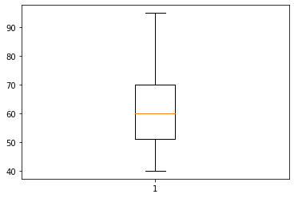

```python
#to show outliers
plt.boxplot(data_frame['age'])
plt.show()
```

#### 4.Data Exploration & Visualisation:

##### 4.1.One-variable plots

###### 4.1.1.Number of Smoking and Non-smoking Patients

The below graph depicts that majority of the people undergoing treatment for heart failure were non-smokers while less than 35% of these people had a habit of smoking. From the histogram we can see that number of non-smoker frequency which is depicted by 0 is more than the frequency of smokers.

```
[Text(0, 0, 'Non-smoking'), Text(1, 0, 'Smoking')]
```

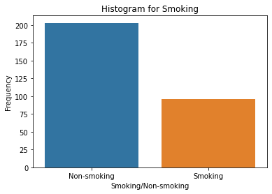

```python
smoking_hist = sns.countplot(data_frame['smoking'])
smoking_hist.set_title('Histogram for Smoking')
smoking_hist.set_ylabel("Frequency")
smoking_hist.set_xlabel("Smoking/Non-smoking")
smoking_hist.set_xticklabels(['Non-smoking', 'Smoking'])
```

###### 4.1.2.Number of Diabetes and non-diabetes patients

The below graph depicts that around 41% of people in this survey suffering from heart failure are diabetic while rest of the patients are non-diabetic.

```
[Text(0, 0, 'No Diabetes'), Text(1, 0, 'Diabetes')]
```

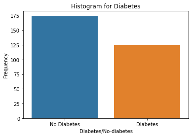

```python
diabetes_hist = sns.countplot(data_frame['diabetes'])
diabetes_hist.set_title('Histogram for Diabetes')
diabetes_hist.set_ylabel("Frequency")
diabetes_hist.set_xlabel("Diabetes/No-diabetes")
diabetes_hist.set_xticklabels(['No Diabetes', 'Diabetes'])
```

###### 4.1.3.Platelets Frequency count for patients

The following graph depicts low(0-150000), normal(150000-450000), and high(450000<) platelet count. Majority of the people suffering from heart failure fall within the normal range. Rest of the ranges have less number of patient present in our dataset.

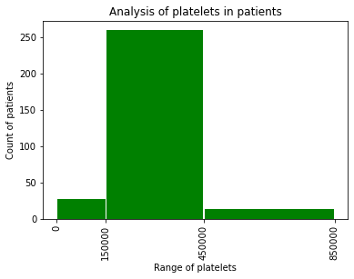

```python
plt.xlabel('Range of platelets')
plt.ylabel('Count of patients')
plt.title('Analysis of platelets in patients')
plt.hist(data_frame['platelets'], bins=[0,150000,450000, 850000], rwidth=0.99, color="g")
x = [0,150000,450000,850000]
labels = ['0', '150000', '450000', '850000']
plt.xticks(x, labels, rotation = "vertical")
plt.show()
```

###### 4.1.4.Serum Creatinine count for patients

Majority of patients have their Serum Creatinine level less than 1.5.

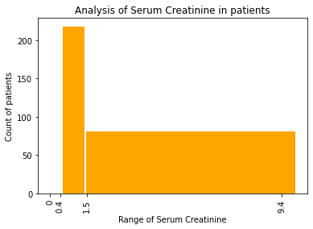

```python
plt.xlabel('Range of Serum Creatinine')
plt.ylabel('Count of patients')
plt.title('Analysis of Serum Creatinine in patients')

plt.hist(data_frame['serum_creatinine'], bins=[0,0.5, 1.4, 10], rwidth=0.99, color="orange")
x = [0,0.4,1.5,9.4]
labels = ['0', '0.4', '1.5', '9.4']
plt.xticks(x, labels, rotation = "vertical")
plt.show()
```

###### 4.1.5.Range for Ejection Fraction in patients

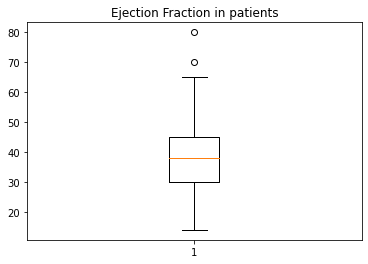

```python
plt.boxplot(data_frame['ejection_fraction'])
plt.title('Ejection Fraction in patients')
```

###### 4.1.6.Frequency for age of patients

The following graph shows people with age 40 and above are more likely to suffer heart failure. Most of the patients are from the age group of above 60. Less number of people lie in the age group between 40 to 60, as compared to the ones that are above 60.

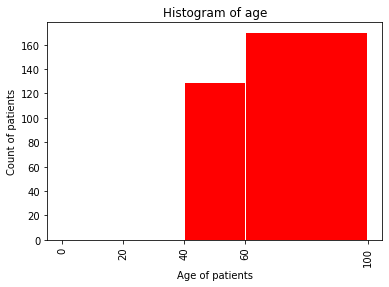

```python
plt.xlabel('Age of patients')
plt.ylabel('Count of patients')
plt.title('Histogram of age')

plt.hist(data_frame['age'], bins=[0,20, 40, 60, 100], rwidth=0.99, color="red")
x = [0,20,40,60, 100]
labels = ['0', '20', '40', '60', '100']
plt.xticks(x, labels, rotation = "vertical")
plt.show()
```

##### 4.2.Two variable plot

###### 4.2.1.Survival Rate for male and female patients

Ratio of male patients suffering from heart failure and leading to death is somewhere equal to the ratio of females suffering heart failure and leading to death.

We can see that more number of male patients had heart failure but they still survived but their death count is also more as compared to females. Most of patients in both categories survived.

```
[Text(0, 0, 'Female'), Text(1, 0, 'Male')]
```

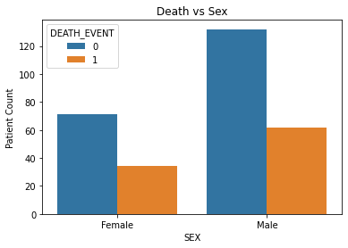

```python
smoking_de_plot = sns.countplot(x = 'sex', hue = 'DEATH_EVENT', data = data_frame)
smoking_de_plot.set_title("Death vs Sex")
smoking_de_plot.set_xlabel("SEX")
smoking_de_plot.set_ylabel("Patient Count")
smoking_de_plot.set_xticklabels(['Female', 'Male'])
```

###### 4.2.2.Survival rate for patients with high blood pressure

Ratio of people having high blood pressure and facing death is more than the ratio of people having normal blood pressure and facing death.

```
[Text(0, 0, 'No high Blood Pressure'), Text(1, 0, 'High Blood Pressure')]
```

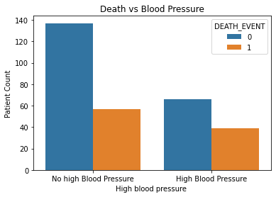

```python
bp_de_plot = sns.countplot(x = 'high_blood_pressure', hue = 'DEATH_EVENT', data = data_frame)
bp_de_plot.set_title("Death vs Blood Pressure")
bp_de_plot.set_xlabel("High blood pressure ")
bp_de_plot.set_ylabel("Patient Count")
bp_de_plot.set_xticklabels(['No high Blood Pressure', 'High Blood Pressure'])
```

###### 4.2.3.Survival rate for patients with diabetes

Ratio of diabetic people facing death is somewhere equal to the ratio of non-diabetic people facing death.

Most of the patients who survived did not have diabetes but we can also see that most of the patients who diabetes also survived. Number of deaths seems to be almost similar in both the cases.

```
[Text(0, 0, 'No Diabetes'), Text(1, 0, 'Diabetes')]
```

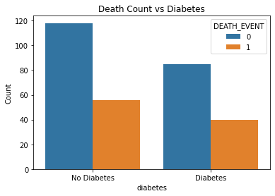

```python
bp_de_plot = sns.countplot(x = 'diabetes', hue = 'DEATH_EVENT', data = data_frame)
bp_de_plot.set_title("Death Count vs Diabetes")
bp_de_plot.set_xlabel("diabetes")
bp_de_plot.set_ylabel("Count")
bp_de_plot.set_xticklabels(['No Diabetes', 'Diabetes'])
```

###### 4.2.4.Survival rate for smoking and non-smoking patients

Ratio of the people alive to the people dead is equal irrespective of whether they are smokers or not.

Patients who do not smoke has most of the people who survived but some of them in this category could survive. In the smoking category we can see that number of patients who survived is more than those who could not make it.

```
[Text(0, 0, 'Non Smoking'), Text(1, 0, 'Smoking')]
```

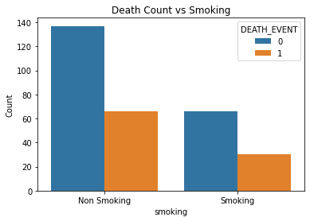

```python
bp_de_plot = sns.countplot(x = 'smoking', hue = 'DEATH_EVENT', data = data_frame)
bp_de_plot.set_title("Death Count vs Smoking")
bp_de_plot.set_xlabel("smoking")
bp_de_plot.set_ylabel("Count")
bp_de_plot.set_xticklabels(['Non Smoking', 'Smoking'])
```

###### 4.3.Three variable plot

###### 4.3.1.Survival Evenets for Smoking/non-smoking people with Ejection Fraction rate

From the following graph it is seen that people who died had low Ejection fraction irrespective of their smoking habit but smokers had least Ejection fraction than non-smokers.

We can see that smoke did not have a effect on Ejection Fraction of the patients. As we can see that number of patients who survived is similar for the smoking and non-smoking category. Sane thing goes with the patients who could not survive for both the categories.

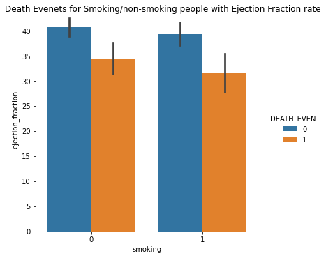

```python
age_smoking_de_plot = sns.catplot(x='smoking', y = 'ejection_fraction', hue = 'DEATH_EVENT', kind = "bar", data = data_frame)

age_smoking_de_plot.fig.suptitle("Death Evenets for Smoking/non-smoking people with Ejection Fraction rate")
```

###### 4.3.2.Survival Evenets for Smoking/non-smoking people with Creatinine phosphokinase

Non smokers who faced death have highest Creatinine phosphokinase.

Pateints who did not smoke and could survive the Creantinine Phosphokinase level less and who dies had this value high. In the smokers category we can see that there was an incease in the levle of Creantinine Phophokinase for patients who survived. But we can see that in this category people with less Creantinine Phosphokinase could not survive the heart failure.

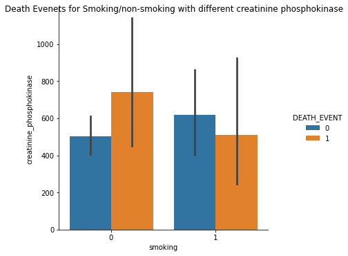

```python
ss_smoking_de_plot = sns.catplot(x='smoking', y = 'creatinine_phosphokinase', hue = 'DEATH_EVENT', kind = "bar", data = data_frame)

ss_smoking_de_plot.fig.suptitle("Death Evenets for Smoking/non-smoking with different creatinine phosphokinase")
```

###### 4.3.3.Serum Sodium level for diabetes patient and their survival rate

Diabetic people have slightly high level of Serum sodium irrespective of whether they live or face death.

In the non-diabetes group we can see that patient who survived had a high level of Serum Sodium. In this category patients who died, most of them had their Serum Sodium reduced. Whereas in diabetes group people who survived had the similar Serum Sodium level as that present in the non-diabetes group. Although in this category people had Serum Sodium at a normal level could not survive.

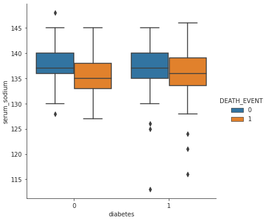

```python
plt.figure(figsize=(20,15))
with sns.axes_style(style = 'ticks'):
    g = sns.factorplot("diabetes", "serum_sodium", "DEATH_EVENT", data = data_frame, kind = "box")
```